# Practicum2

Thomas Faria, Caitlin Kirkpatrick, Sairah Shir

2024-07-14

### Loading and data exploration

```r
# Load data
bed_type_df <- read_csv("data/bed_type.csv", show_col_types = FALSE)
bed_fact_df <- read_csv("data/bed_fact.csv", show_col_types = FALSE)
business_df <- read_csv("data/business.csv", show_col_types = FALSE)
```

```r
# Explore data

# Summary of bed_type_df
summary(bed_type_df)
```

```
##      bed_id        bed_code           bed_desc
##  Min.   : 1.00   Length:20          Length:20
##  1st Qu.: 5.75   Class :character   Class :character
##  Median :10.50   Mode  :character   Mode  :character
##  Mean   :10.50
##  3rd Qu.:15.25
##  Max.   :20.00
```

```r
# Summary of bed_fact_df
summary(bed_fact_df)
```

```
##   ims_org_id            bed_id       license_beds     census_beds
##  Length:51458       Min.   : 1.00   Min.   :   1.0   Min.   :   0.00
##  Class :character   1st Qu.: 8.00   1st Qu.:  41.0   1st Qu.:  29.00
##  Mode  :character   Median : 8.00   Median :  86.0   Median :  66.00
##                     Mean   :11.94   Mean   : 104.2   Mean   :  81.27
##                     3rd Qu.:18.00   3rd Qu.: 127.8   3rd Qu.: 110.00
##                     Max.   :20.00   Max.   :2007.0   Max.   :1505.00
##   staffed_beds
##  Min.   :   0.00
##  1st Qu.:  39.00
##  Median :  83.00
##  Mean   :  99.17
##  3rd Qu.: 124.00
##  Max.   :1527.00
```

```r
# Summary of business_df
summary(business_df)
```

```
##   ims_org_id        business_name      ttl_license_beds ttl_census_beds
##  Length:22202       Length:22202       Min.   :   2.0   Min.   :   0.00
##  Class :character   Class :character   1st Qu.:  59.0   1st Qu.:  44.00
##  Mode  :character   Mode  :character   Median :  99.0   Median :  80.00
##                                        Mean   : 120.8   Mean   :  94.19
##                                        3rd Qu.: 140.0   3rd Qu.: 117.00
##                                        Max.   :2007.0   Max.   :1505.00
##  ttl_staffed_beds bed_cluster_id
##  Min.   :   0.0   Min.   :1.000
##  1st Qu.:  56.0   1st Qu.:1.000
##  Median :  98.0   Median :1.000
##  Mean   : 114.9   Mean   :1.455
##  3rd Qu.: 136.0   3rd Qu.:2.000
##  Max.   :1527.0   Max.   :9.000
```

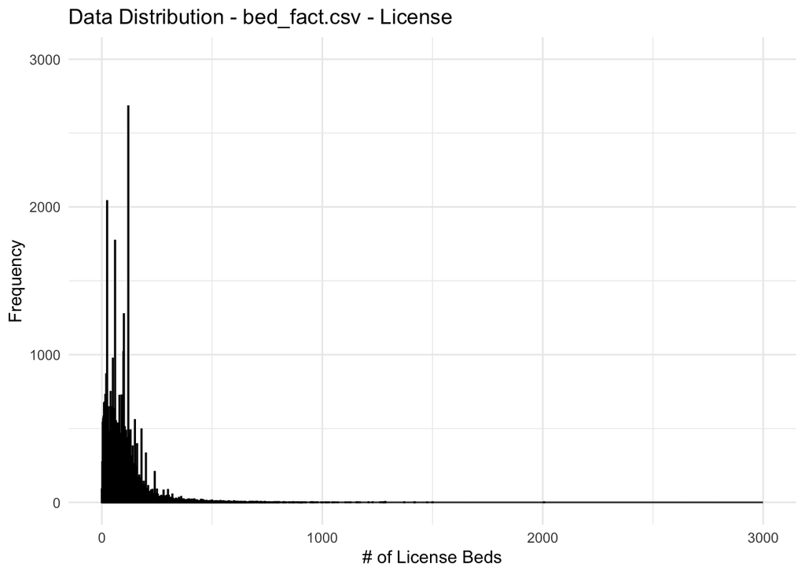

```r
# Basic histograms for outlier visualization
ggplot(bed_fact_df, aes(x = license_beds)) +
  geom_histogram(binwidth = 2, color = "black") +
  scale_x_continuous(limits = c(-1, 3000)) +
  scale_y_continuous(limits = c(-1, 3000)) +
  labs(title = "Data Distribution - bed_fact.csv - License", x = "# of License Beds", y = "Frequency") +
  theme_minimal()
```

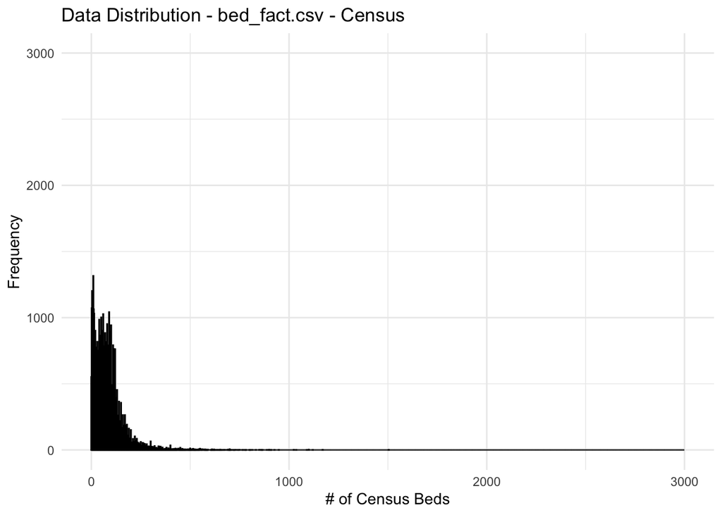

```r
ggplot(bed_fact_df, aes(x = census_beds)) +
  geom_histogram(binwidth = 2, color = "black") +
  scale_x_continuous(limits = c(-1, 3000)) +
  scale_y_continuous(limits = c(-1, 3000)) +
  labs(title = "Data Distribution - bed_fact.csv - Census", x = "# of Census Beds", y = "Frequency") +
  theme_minimal()
```

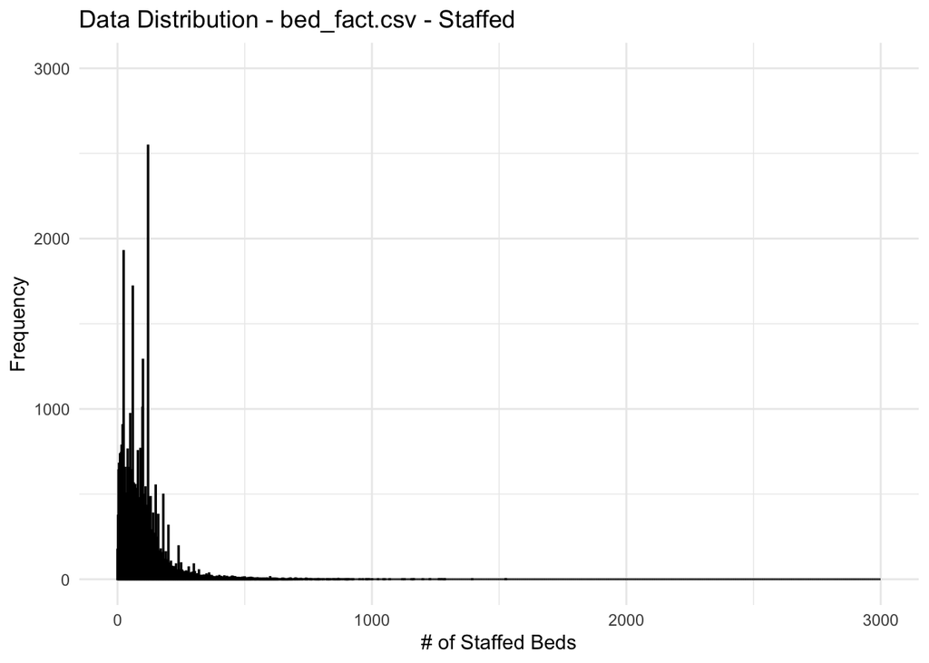

```r
ggplot(bed_fact_df, aes(x = staffed_beds)) +
  geom_histogram(binwidth = 2, color = "black") +
  scale_x_continuous(limits = c(-1, 3000)) +
  scale_y_continuous(limits = c(-1, 3000)) +
  labs(title = "Data Distribution - bed_fact.csv - Staffed", x = "# of Staffed Beds", y = "Frequency") +
  theme_minimal()
```

#### Create SQL Database

- bed_fact_table, bed_type_table, and business_table are loaded from their corresponding R data frames into the “p2_db” database and a connection is established for later reference

```r
# Add data to a new database for downstream SQL queries
# Establish and open connection to existing database file
p2_connection <- dbConnect(RSQLite::SQLite(), "p2_db.sqlite")

# Function to check if table already exists in p2_db
table_exists <- function(con, table_name) {
  query <- sprintf("SELECT name FROM sqlite_master WHERE type='table' AND name='%s';", table_name)
  result <- dbGetQuery(con, query)
  return(nrow(result) > 0)
}

# Create bed_type_table, if it doesn't already exist
if (!table_exists(p2_connection, "bed_type_table")) {
  dbExecute(p2_connection, "
    CREATE TABLE bed_type_table (
      bed_id INTEGER PRIMARY KEY,
      bed_code TEXT,
      bed_desc TEXT
    );
  ")
}

# Create bed_fact_table, if it doesn't already exist
if (!table_exists(p2_connection, "bed_fact_table")) {
  dbExecute(p2_connection, "
    CREATE TABLE bed_fact_table (
      ims_org_id TEXT,
      bed_id INTEGER,
      license_beds INTEGER,
      census_beds INTEGER,
      staffed_beds INTEGER,
      PRIMARY KEY (ims_org_id, bed_id)
    );
  ")
}

# Create business_table, if it doesn't already exist
if (!table_exists(p2_connection, "business_table")) {
  dbExecute(p2_connection, "
    CREATE TABLE business_table (
      ims_org_id TEXT,
      business_name TEXT,
      ttl_license_beds INTEGER,
      ttl_census_beds INTEGER,
      ttl_staffed_beds INTEGER,
      bed_cluster_id INTEGER,
      PRIMARY KEY (ims_org_id, bed_cluster_id)
    );
  ")
}

# Load data into each table
dbWriteTable(p2_connection, "bed_type_table", bed_type_df, overwrite = TRUE, row.names = FALSE)
dbWriteTable(p2_connection, "bed_fact_table", bed_fact_df, overwrite = TRUE, row.names = FALSE)
dbWriteTable(p2_connection, "business_table", business_df, overwrite = TRUE, row.names = FALSE)
```

#### Using JOIN to Create a Combined Table

- combined_table is created from the existing fact/dimension tables and then loaded into combined_df for downstream R analysis

```r
# Create combined_table, if it doesn't already exist
if (!table_exists(p2_connection, "combined_table")) {
  dbExecute(p2_connection, "
    CREATE TABLE combined_table (
      ims_org_id TEXT,
      business_name TEXT,
      ttl_license_beds INTEGER,
      ttl_census_beds INTEGER,
      ttl_staffed_beds INTEGER,
      bed_cluster_id INTEGER,
      bed_id INTEGER,
      license_beds INTEGER,
      census_beds INTEGER,
      staffed_beds INTEGER,
      bed_code TEXT,
      bed_desc TEXT,
      PRIMARY KEY (ims_org_id, bed_id)
    );
  ")
  # Insert data from other db tables
  dbExecute(p2_connection, "
    INSERT INTO combined_table
    SELECT business_table.ims_org_id,
           business_table.business_name,
           business_table.ttl_license_beds,
           business_table.ttl_census_beds,
           business_table.ttl_staffed_beds,
           business_table.bed_cluster_id,
           bed_fact_table.bed_id,
           bed_fact_table.license_beds,
           bed_fact_table.census_beds,
           bed_fact_table.staffed_beds,
           bed_type_table.bed_code,
           bed_type_table.bed_desc
    FROM business_table
    JOIN bed_fact_table ON business_table.ims_org_id = bed_fact_table.ims_org_id
    JOIN bed_type_table ON bed_fact_table.bed_id = bed_type_table.bed_id;
  ")
}

# Create combined dataframe
combined_df <- dbGetQuery(p2_connection, "SELECT * FROM combined_table")
head(combined_df)
```

```
##    ims_org_id                   business_name ttl_license_beds ttl_census_beds
## 1 INS00077200 140 Prescott Street Corporation              126             122
## 2 INS00077200 140 Prescott Street Corporation              126             122
## 3 INS00000594             366th Medical Group               10               4
## 4 INS00000594             366th Medical Group               10               4
## 5 INS00039181        7 Hills Pediatric Center               83              75
## 6 INS00039181        7 Hills Pediatric Center               83              75
##   ttl_staffed_beds bed_cluster_id bed_id license_beds census_beds staffed_beds
## 1              126              2      8          126         122          126
## 2              126              2     18          126         122          126
## 3               10              1      5           10           4           10
## 4               10              1     18           10           4           10
## 5               83              1      8           83          75           83
## 6               83              1     18           83          75           83
##   bed_code         bed_desc
## 1       NF Nursing Facility
## 2       TO            Total
## 3       MS         Med/Surg
## 4       TO            Total
## 5       NF Nursing Facility
## 6       TO            Total
```

#### Outlier Identification

```r
# Compute outliers for each bed type in the combined_df
bed_type_outliers <- combined_df %>%
  mutate(
    mean_license_beds = mean(ttl_license_beds, na.rm = TRUE),
    mean_census_beds = mean(ttl_census_beds, na.rm = TRUE),
    mean_staffed_beds = mean(ttl_staffed_beds, na.rm = TRUE),
    sd_license_beds = sd(ttl_license_beds, na.rm = TRUE),
    sd_census_beds = sd(ttl_census_beds, na.rm = TRUE),
    sd_staffed_beds = sd(ttl_staffed_beds, na.rm = TRUE)
  ) %>%
  # Relative to the mean, any values on the lower or upper bounds that are 3 times the standard deviation are filtered
  filter(ttl_license_beds < mean_license_beds - 3 * sd_license_beds | ttl_license_beds > mean_license_beds + 3 * sd_license_beds) %>%
  filter(ttl_census_beds < mean_census_beds - 3 * sd_census_beds | ttl_census_beds > mean_census_beds + 3 * sd_census_beds) %>%
  filter(ttl_staffed_beds < mean_staffed_beds - 3 * sd_staffed_beds | ttl_staffed_beds > mean_staffed_beds + 3 * sd_staffed_beds) %>%
  select(ttl_license_beds, ttl_census_beds, ttl_staffed_beds)

summary(bed_type_outliers)
```

```
##  ttl_license_beds ttl_census_beds ttl_staffed_beds
##  Min.   : 570.0   Min.   : 420    Min.   : 519.0
##  1st Qu.: 650.0   1st Qu.: 493    1st Qu.: 600.0
##  Median : 743.0   Median : 554    Median : 680.0
##  Mean   : 802.1   Mean   : 604    Mean   : 740.1
##  3rd Qu.: 900.8   3rd Qu.: 652    3rd Qu.: 850.0
##  Max.   :2007.0   Max.   :1505    Max.   :1527.0
```

#### Verify Composite PKs

```r
# Verify the uniqueness of the composite primary keys used in bed_fact_table (combination of ims_org_id and bed_id) and business_table (combination of ims_org_id and bed_cluster_id)

duplicate_keys <- dbGetQuery(p2_connection, "
                             SELECT ims_org_id, bed_id, COUNT(*)
                             FROM bed_fact_table
                             GROUP BY ims_org_id, bed_id
                             HAVING COUNT(*) > 1;
                             ")

if (nrow(duplicate_keys) == 0) {
  print("Composite PK is unique for all combinations of ims_org_id and bed_id in bed_fact_table.")
} else {
  print("Duplicate keys found in bed_fact_table !! Composite PK is not valid.")
  print(duplicate_keys)
}
```

```
## [1] "Composite PK is unique for all combinations of ims_org_id and bed_id in bed_fact_table."
```

```r
duplicate_keys <- dbGetQuery(p2_connection, "
                             SELECT ims_org_id, bed_cluster_id, COUNT(*)
                             FROM business_table
                             GROUP BY ims_org_id, bed_cluster_id
                             HAVING COUNT(*) > 1;
                             ")

if (nrow(duplicate_keys) == 0) {
  print("Composite PK is unique for all combinations of ims_org_id and bed_cluster_id in business_table.")
} else {
  print("Duplicate keys found in business_table !! Composite PK is not valid.")
  print(duplicate_keys)
}
```

```
## [1] "Composite PK is unique for all combinations of ims_org_id and bed_cluster_id in business_table."
```

### Identification of Facts/Dimensions in bed_type.csv and business.csv

#### Dimensions

- bed_type.csv contains three dimensions that are qualitative attributes providing context for or categorizing a fact object:
  - bed_id (primary key) assigns a unique identifier for each type of bed
  - bed_code contains abbreviations for each type of bed
  - bed_desc contains descriptions of each type of bed
- business.csv contains three dimensions that are qualitative attributes providing context for or categorizing a fact object:
  - ims_org_id (primary key) assigns a unique identifier for each business
  - business_name contains the names of the organizations
  - bed_cluster_id categorizes bed clusters from 1-9

#### Facts

- The remaining columns in business.csv (ttl_license_beds, ttl_census_beds, and ttl_staffed_bed)s are facts due to their quantitative nature

### Identification of Facts/Dimensions in bed_fact.csv

#### Facts

- bed_fact.csv has four facts:
  - bed_id, license_beds, census_beds, staffed_beds are all facts since they report quantitative data

### Initial Analysis for Leadership

#### License Beds (ICU and SICU Separated)

```r
license_beds_icu <- "SELECT business_name AS hospital_name,
SUM(license_beds) AS total_license_beds_icu
FROM combined_table
WHERE bed_id = 4
GROUP BY hospital_name
ORDER BY total_license_beds_icu DESC
LIMIT 10"

license_beds_icu_df <- dbGetQuery(p2_connection, license_beds_icu)
license_beds_icu_df
```

```
##                                          hospital_name total_license_beds_icu
## 1                           Phoenix Childrens Hospital                    247
## 2                           Wesley Medical Center, LLC                    214
## 3                                Vidant Medical Center                    204
## 4            Rady Childrens Hospital and Health Center                    200
## 5                   Dallas County Hospital Association                    195
## 6  Saint Lukes Episcopal Hospital Texas Medical Center                    178
## 7                               The Methodist Hospital                    170
## 8                            Emory University Hospital                    169
## 9                                Miami Valley Hospital                    164
## 10                    Mercy Medical Center Saint Louis                    163
```

```r
license_beds_sicu <- "SELECT business_name AS hospital_name,
SUM(license_beds) AS total_license_beds_sicu
FROM combined_table
WHERE bed_id = 15
GROUP BY hospital_name
ORDER BY total_license_beds_sicu DESC
LIMIT 10"

license_beds_sicu_df <- dbGetQuery(p2_connection, license_beds_sicu)
license_beds_sicu_df
```

```
##                                     hospital_name total_license_beds_sicu
## 1    Shands Hospital at the University of Florida                     159
## 2                     Brigham and Womens Hospital                     138
## 3           University of Maryland Medical Center                     116
## 4                        Carolinas Medical Center                      98
## 5             University Hospital in Bexar County                      96
## 6       Saint Josephs Hospital and Medical Center                      96
## 7                   Duke University Health System                      94
## 8      Hospital of the University of Pennsylvania                      79
## 9          Saint Vincent Infirmary Medical Center                      77
## 10 Dell Childrens Medical Center of Central Texas                      73
```

#### Census Beds (ICU and SICU Separated)

```r
# Sairah

census_beds_icu <- "SELECT business_name AS hospital_name,
SUM(census_beds) AS total_census_beds_icu
FROM combined_table
WHERE bed_id = 4
GROUP BY hospital_name
ORDER BY total_census_beds_icu DESC
LIMIT 10"

census_beds_icu_df <- dbGetQuery(p2_connection, census_beds_icu)
census_beds_icu_df
```

```
##                                                              hospital_name
## 1                                       Dallas County Hospital Association
## 2                                         Mercy Medical Center Saint Louis
## 3  Los Angeles County University of Southern California Healthcare Network
## 4                                                   The Methodist Hospital
## 5                                                    Vidant Medical Center
## 6        Ronald Reagan University of California Los Angeles Medical Center
## 7                                        Lakeshore Mental Health Institute
## 8                                                Emory University Hospital
## 9                                               Phoenix Childrens Hospital
## 10                                              Delray Medical Center, Inc
##    total_census_beds_icu
## 1                    145
## 2                    142
## 3                    139
## 4                    138
## 5                    123
## 6                    122
## 7                    120
## 8                    120
## 9                    117
## 10                   114
```

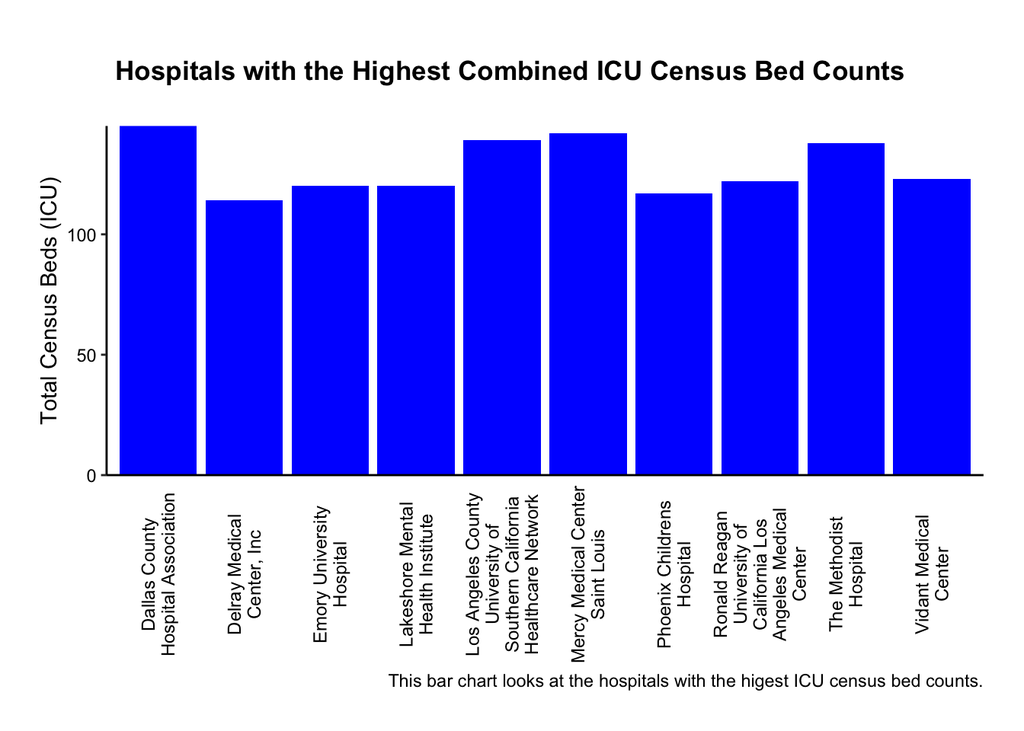

```r
ggplot(census_beds_icu_df, aes(x = hospital_name, y = total_census_beds_icu)) +
  geom_bar(stat = "identity", fill = "blue") +
  labs(
  x = "Hospital Name",
  y = "Total Census Beds (ICU)",
  title = "Hospitals with the Highest Combined ICU Census Bed Counts",
  caption = "This bar chart looks at the hospitals with the higest ICU census bed counts."
  ) +
  scale_y_continuous(expand = c(0, 0), limits = c(0, NA)) +
  scale_x_discrete(labels = function(x) str_wrap(x, width = 20)) +
  theme_classic() +
  theme(
  axis.text.x = element_text(angle = 90, hjust = 0.5, vjust = 0.5, size = 9, color = "black"),
  axis.title.x = element_blank(),
  axis.ticks.x = element_blank(),
  legend.title = element_text(face = "bold"),
  axis.text.y = element_text(color = "black"),
  axis.title.y = element_text(color = "black"),
  plot.title = element_text(hjust = 0.1, face = "bold", margin = margin(b = 20)),
  plot.margin = margin(t = 30, r = 20, l = 20, b = 20)
  )
```

```r
census_beds_sicu <- "SELECT business_name AS hospital_name,
SUM(census_beds) AS total_census_beds_sicu
FROM combined_table
WHERE bed_id = 15
GROUP BY hospital_name
ORDER BY total_census_beds_sicu DESC
LIMIT 10"

census_beds_sicu_df <- dbGetQuery(p2_connection, census_beds_sicu)
census_beds_sicu_df
```

```
##                                   hospital_name total_census_beds_sicu
## 1  Shands Hospital at the University of Florida                    159
## 2                   Brigham and Womens Hospital                    124
## 3                 Duke University Health System                     76
## 4                      Carolinas Medical Center                     76
## 5         University of Maryland Medical Center                     67
## 6        Saint Vincent Infirmary Medical Center                     62
## 7          Vanderbilt University Medical Center                     61
## 8           University Hospital in Bexar County                     61
## 9    Hospital of the University of Pennsylvania                     61
## 10              The Cleveland Clinic Foundation                     57
```

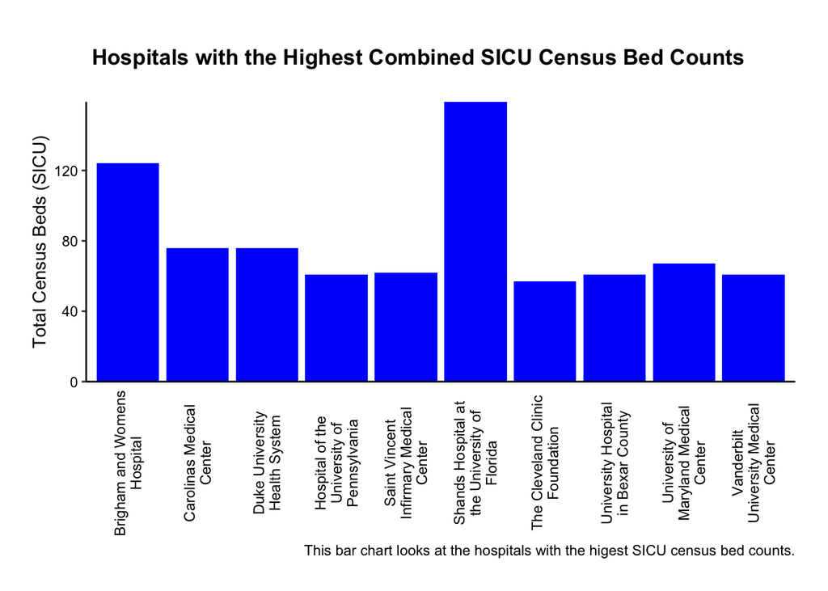

```r
ggplot(census_beds_sicu_df, aes(x = hospital_name, y = total_census_beds_sicu)) +
  geom_bar(stat = "identity", fill = "blue") +
  labs(
  x = "Hospital Name",
  y = "Total Census Beds (SICU)",
  title = "Hospitals with the Highest Combined SICU Census Bed Counts",
  caption = "This bar chart looks at the hospitals with the higest SICU census bed counts."
  ) +
  scale_y_continuous(expand = c(0, 0), limits = c(0, NA)) +
  scale_x_discrete(labels = function(x) str_wrap(x, width = 20)) +
  theme_classic() +
  theme(
  axis.text.x = element_text(angle = 90, hjust = 0.5, vjust = 0.5, size = 9, color = "black"),
  axis.title.x = element_blank(),
  axis.ticks.x = element_blank(),
  legend.title = element_text(face = "bold"),
  axis.text.y = element_text(color = "black"),
  axis.title.y = element_text(color = "black"),
  plot.title = element_text(hjust = 0.1, face = "bold", margin = margin(b = 20)),
  plot.margin = margin(t = 30, r = 20, l = 20, b = 20)
  )
```

#### Staffed Beds (ICU and SICU Separated)

```r
get_staffed_beds_total <- "SELECT business_name AS hospital_name,
                                 --- Take the sum of the staffed beds in a new column total_icu_sicu_staffed_beds ---
                                 SUM(staffed_beds) AS total_icu_sicu_staffed_beds
                          FROM combined_table
                          --- Only include rows where bed_id is 4 (ICU) or 15 (SICU) ---
                          WHERE bed_id IN (4, 15)
                          --- Group by hospital_name ---
                          GROUP BY hospital_name
                          --- Arrange in descending order ---
                          ORDER BY total_icu_sicu_staffed_beds DESC
                          --- Only include top 10 hospitals ---
                          LIMIT 10;"

total_staffed_beds <- dbGetQuery(p2_connection, get_staffed_beds_total) %>%
  as_tibble() %>%
  mutate(
    total_icu_sicu_staffed_beds = as.numeric(total_icu_sicu_staffed_beds)
  )
total_staffed_beds
```

```
## # A tibble: 10 × 2
##    hospital_name                                total_icu_sicu_staffed_beds
##    <chr>                                                              <dbl>
##  1 Vidant Medical Center                                                203
##  2 Rady Childrens Hospital and Health Center                            200
##  3 University of Maryland Medical Center                                171
##  4 Emory University Hospital                                            169
##  5 Shands Hospital at the University of Florida                         167
##  6 Mercy Medical Center Saint Louis                                     163
##  7 Wesley Medical Center, LLC                                           162
##  8 Phoenix Childrens Hospital                                           159
##  9 Grady Memorial Hospital                                              154
## 10 UC Health University Hospital                                        151
```

```r
# Query for the visual
staffed_beds_separate_visual <- "SELECT business_name AS hospital_name,
                                 SUM(CASE WHEN bed_desc = 'ICU' THEN staffed_beds ELSE 0 END) AS ICU_beds,
                                 SUM(CASE WHEN bed_desc = 'SICU' THEN staffed_beds ELSE 0 END) AS SICU_beds,
                                 SUM(staffed_beds) AS total_icu_sicu_staffed_beds
                          FROM combined_table
                          --- Only include rows where bed_id is 4 (ICU) or 15 (SICU) ---
                          WHERE bed_desc IN ('ICU', 'SICU')
                          GROUP BY hospital_name
                          --- Arrange in descending order ---
                          ORDER BY total_icu_sicu_staffed_beds DESC;"

# Create new dataframe for visual
separate_staffed_beds_df <- dbGetQuery(p2_connection, staffed_beds_separate_visual) %>%
  as_tibble() %>%
  slice(1:10) %>%
  rename(ICU = ICU_beds,
         SICU = SICU_beds)
separate_staffed_beds_df
```

```
## # A tibble: 10 × 4
##    hospital_name                                ICU  SICU total_icu_sicu_staff…¹
##    <chr>                                      <int> <int>                  <int>
##  1 Vidant Medical Center                        203     0                    203
##  2 Rady Childrens Hospital and Health Center    200     0                    200
##  3 University of Maryland Medical Center         81    90                    171
##  4 Emory University Hospital                    169     0                    169
##  5 Shands Hospital at the University of Flor…     8   159                    167
##  6 Mercy Medical Center Saint Louis             163     0                    163
##  7 Wesley Medical Center, LLC                   162     0                    162
##  8 Phoenix Childrens Hospital                   159     0                    159
##  9 Grady Memorial Hospital                       98    56                    154
## 10 UC Health University Hospital                112    39                    151
## # ℹ abbreviated name: ¹total_icu_sicu_staffed_beds
```

```r
pivot_staffed_beds_df <- separate_staffed_beds_df %>%
  pivot_longer(cols = c(ICU, SICU), names_to = "bed_type", values_to = "bed_count")
```

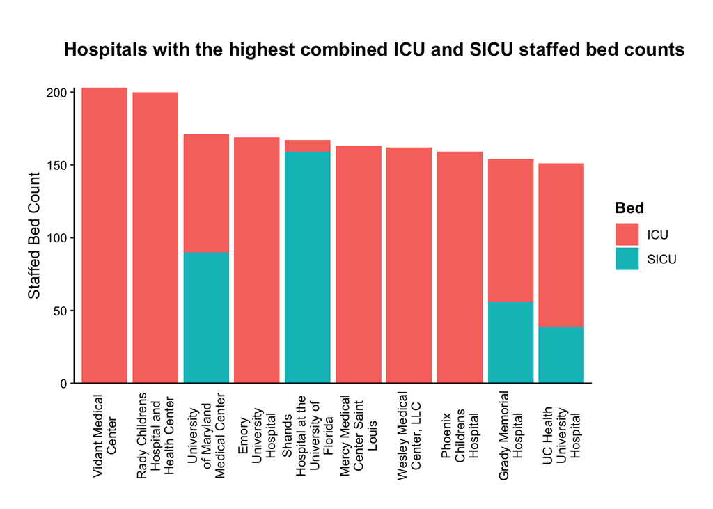

```r
# Stacked bar for better visualization of ICU and SICU beds for top 10 hospitals
ggplot(pivot_staffed_beds_df, aes(reorder(hospital_name, -bed_count), bed_count, fill = bed_type)) +
  geom_bar(stat = "identity") +
  labs(
  x = "Hospital Name",
  y = "Staffed Bed Count",
  fill = "Bed",
  title = "Hospitals with the highest combined ICU and SICU staffed bed counts"
  ) +
  scale_y_continuous(expand = c(0, 0), limits = c(0, NA)) +
  scale_x_discrete(labels = function(x) str_wrap(x, width = 15)) +
  theme_classic() +
  theme(
  axis.text.x = element_text(angle = 90, hjust = 0.5, vjust = 0.5, size = 9, color = "black"),
  axis.title.x = element_blank(),
  axis.ticks.x = element_blank(),
  legend.title = element_text(face = "bold"),
  axis.text.y = element_text(color = "black"),
  axis.title.y = element_text(color = "black"),
  plot.title = element_text(hjust = 0.1, face = "bold", margin = margin(b = 20)),
  plot.margin = margin(t = 30, r = 20, l = 20, b = 20)
  )
```

### Follow-up Analysis for Leadership (identifying hospitals with both ICU and SICU volume sufficiency)

#### License Beds (ICU and SICU Combined - min. 1 bed of each type per hospital)

```r
# Thomas

license_beds_combined <- "SELECT business_name AS hospital_name,
SUM(license_beds) AS total_license_beds_combined
FROM combined_table
WHERE (bed_id = 4 OR bed_id = 15)
GROUP BY hospital_name
HAVING COUNT(DISTINCT CASE WHEN bed_id = 4 THEN 1 END) > 0
AND COUNT(DISTINCT CASE WHEN bed_id = 15 THEN 1 END) > 0
ORDER BY total_license_beds_combined DESC
LIMIT 10;"

license_beds_combined_df <- dbGetQuery(p2_connection, license_beds_combined) %>%
  as_tibble()
license_beds_combined_df
```

```
## # A tibble: 10 × 2
##    hospital_name                                   total_license_beds_combined
##    <chr>                                                                 <int>
##  1 University of Maryland Medical Center                                   220
##  2 UC Health University Hospital                                           218
##  3 Shands Hospital at the University of Florida                            167
##  4 MCGHealth, Inc                                                          155
##  5 Grady Memorial Hospital                                                 154
##  6 Jackson Memorial Hospital                                               151
##  7 University of Minnesota Medical Center Fairview                         144
##  8 University Hospital in Bexar County                                     144
##  9 Carolinas Medical Center                                                137
## 10 Yale New Haven Hospital                                                 136
```

#### Census Beds (ICU and SICU Combined - min. 1 bed of each type per hospital)

```r
# Sairah

census_beds_combined <- "SELECT business_name AS hospital_name,
SUM(census_beds) AS total_census_beds_combined
FROM combined_table
WHERE (bed_id = 4 OR bed_id = 15)
GROUP BY hospital_name
HAVING COUNT(DISTINCT CASE WHEN bed_id = 4 THEN 1 END) > 0
AND COUNT(DISTINCT CASE WHEN bed_id = 15 THEN 1 END) > 0
ORDER BY total_census_beds_combined DESC
LIMIT 10;"

census_beds_combined_df <- dbGetQuery(p2_connection, census_beds_combined) %>%
  as_tibble()

census_beds_combined_df
```

```
## # A tibble: 10 × 2
##    hospital_name                                   total_census_beds_combined
##    <chr>                                                                <int>
##  1 Shands Hospital at the University of Florida                           167
##  2 University of Minnesota Medical Center Fairview                        129
##  3 University of Maryland Medical Center                                  127
##  4 Jackson Memorial Hospital                                              117
##  5 UC Health University Hospital                                          110
##  6 Carolinas Medical Center                                               106
##  7 Cedars Sinai Health System                                              92
##  8 University Hospital in Bexar County                                     91
##  9 Duke University Health System                                           91
## 10 The Cleveland Clinic Foundation                                         88
```

```r
census_beds_combined_visual <- "SELECT business_name AS hospital_name,
SUM(CASE WHEN bed_id = 4 THEN census_beds ELSE 0 END) AS ICU_beds,
SUM(CASE WHEN bed_id = 15 THEN census_beds ELSE 0 END) AS SICU_beds,
SUM(census_beds) AS total_icu_sicu_beds
FROM combined_table
WHERE (bed_id = 4 OR bed_id = 15)
GROUP BY hospital_name
HAVING COUNT(DISTINCT CASE WHEN bed_id = 4 THEN 1 END) > 0
AND COUNT(DISTINCT CASE WHEN bed_id = 15 THEN 1 END) > 0
ORDER BY total_icu_sicu_beds DESC
LIMIT 10;"

census_beds_combined_df <- dbGetQuery(p2_connection, census_beds_combined_visual) %>%
  as_tibble %>%
  slice(1:10) %>%
  rename(ICU = ICU_beds,
         SICU = SICU_beds)

census_beds_combined_df
```

```
## # A tibble: 10 × 4
##    hospital_name                                   ICU  SICU total_icu_sicu_beds
##    <chr>                                         <int> <int>               <int>
##  1 Shands Hospital at the University of Florida      8   159                 167
##  2 University of Minnesota Medical Center Fairv…    93    36                 129
##  3 University of Maryland Medical Center            60    67                 127
##  4 Jackson Memorial Hospital                        65    52                 117
##  5 UC Health University Hospital                    82    28                 110
##  6 Carolinas Medical Center                         30    76                 106
##  7 Cedars Sinai Health System                       46    46                  92
##  8 University Hospital in Bexar County              30    61                  91
##  9 Duke University Health System                    15    76                  91
## 10 The Cleveland Clinic Foundation                  31    57                  88
```

```r
pivot_combined_census_beds_df <- census_beds_combined_df %>%
  pivot_longer(cols = c(ICU, SICU), names_to = "bed_type", values_to = "bed_count")
```

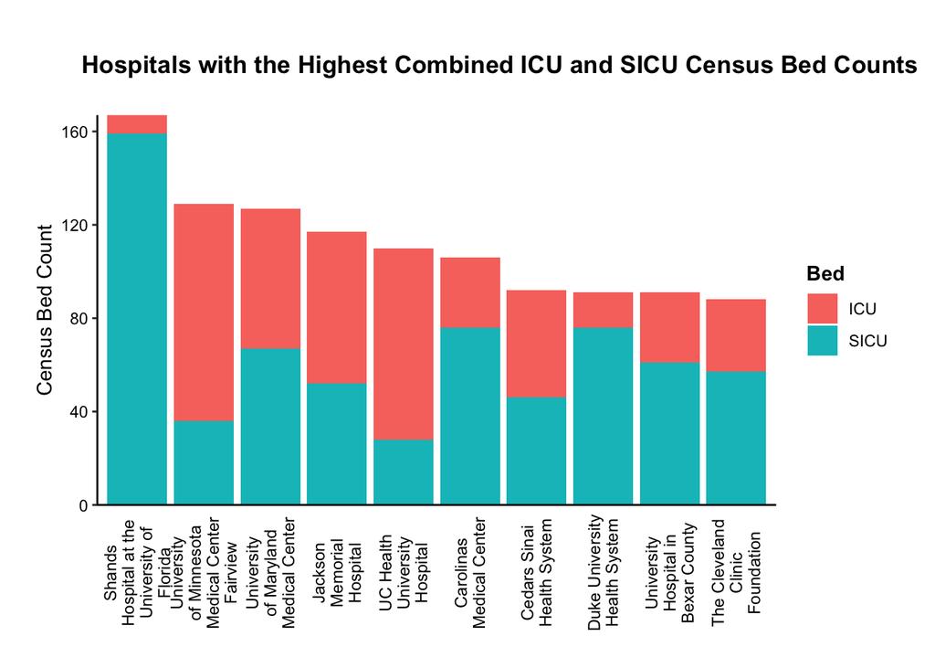

```r
# Bar Chart for ICU and SICU Census Beds for Top 10 Hospitals

ggplot(pivot_combined_census_beds_df, aes(x = reorder(hospital_name, -bed_count), y = bed_count, fill = bed_type)) +
  geom_bar(stat = "identity") +
  labs(
    x = "Hospital Name",
    y = "Census Bed Count",
    fill = "Bed",
    title = "Hospitals with the Highest Combined ICU and SICU Census Bed Counts"
  ) +
  scale_y_continuous(expand = c(0, 0), limits = c(0, NA)) +
  scale_x_discrete(labels = function(x) str_wrap(x, width = 15)) +
  theme_classic() +
  theme(
    axis.text.x = element_text(angle = 90, hjust = 0.5, vjust = 0.5, size = 9, color = "black"),
    axis.title.x = element_blank(),
    axis.ticks.x = element_blank(),
    legend.title = element_text(face = "bold"),
    axis.text.y = element_text(color = "black"),
    axis.title.y = element_text(color = "black"),
    plot.title = element_text(hjust = 0.1, face = "bold", margin = margin(b = 20)),
    plot.margin = margin(t = 30, r = 20, l = 20, b = 20)
  )
```